# Méthodes biostatistiques

ANOVA et comparaisons multiples

Les paramètres suivants doivent être définis dans R ou RStudio afin de reproduire les analyses présentées dans ce document. Les packages `ggplot2`, `hrbrthemes`, `directlabels`, `Hmisc` et `multcomp` ne font pas partie de la distribution R et doivent être installés au préalable si nécessaire :

```r
install.packages(c("ggplot2", "hrbrthemes", "directlabels", "Hmisc", "multcomp"))
```

Les dépendances de ces packages seront installées automatiquement. On supposera également que les instructions R sont exécutées dans un répertoire de travail avec les fichiers de données accessibles dans un sous-répertoire `data/`. Si ce n’est pas le cas, il suffit de créer un sous-répertoire `data/` et d’y enregistrer les fichiers de données, ou de redéfinir les chemins d’accès dans les instructions de lecture des fichiers de données ci-après.

```r
library(ggplot2)
library(hrbrthemes)
library(directlabels)
library(Hmisc)
library(multcomp)
options(digits = 6, show.signif.stars = FALSE)
theme_set(theme_ipsum(base_size = 11))
```

# Rappels sur l’ANOVA à un facteur

Soit $y_{ij}$ la $j$ème observation dans le groupe $i$. Le modèle d’ANOVA ou “effect model” s’écrit
$$y_{ij}=\mu+\alpha_i+\varepsilon_{ij},$$
où $\mu$ désigne la moyenne générale, $\alpha_i$ l’effet du groupe $i$, et $\varepsilon_{ij}\sim \mathcal{N}(0,\sigma^2)$ un terme d’erreur aléatoire. On impose généralement que $\sum_{i=1}^k\alpha_i=0$.

L’hypothèse nulle se lit $H_0:\alpha_1=\alpha_2=\dots=\alpha_k$. Sous cette hypothèse d’égalité des moyennes de groupe, la variance entre groupe (“between”) et la variance propre à chaque groupe (“within”) permettent d’estimer $\sigma^2$. D’où le test F d’égalité de ces deux variances. Sous $H_0$, le rapport entre les carrés moyens inter et intra-groupe (qui estiment les variances ci-dessus) suit une loi F de Fisher-Snedecor à $k-1$ et $N-k$ degrés de liberté.

## Chargement des données

On utilise les données sur le polymorphisme du gène du récepteur estrogène, `polymorphism.dta`. Le chargement des données au format Stata nécessite le package `foreign` et peut être réalisé comme suit :

```r
d <- foreign::read.dta("data/polymorphism.dta")
str(d)
```

```
## 'data.frame':    59 obs. of  3 variables:
##  $ id      : num  1 2 3 4 5 6 7 8 9 10 ...
##  $ age     : num  43 47 55 57 61 63 63 69 70 72 ...
##  $ genotype: Factor w/ 3 levels "1.6/1.6","1.6/0.7",..: 1 1 1 1 1 1 1 1 1 1 ...
##  - attr(*, "datalabel")= chr ""
##  - attr(*, "time.stamp")= chr "16 Apr 2001 14:58"
##  - attr(*, "formats")= chr  "%9.0g" "%9.0g" "%9.0g"
##  - attr(*, "types")= int  102 102 102
##  - attr(*, "val.labels")= chr  "" "" "rflp"
##  - attr(*, "var.labels")= chr  "ID Number" "Age at Diagnosis" "Genotype"
##  - attr(*, "version")= int 7
##  - attr(*, "label.table")=List of 1
##   ..$ rflp: Named int  1 2 3
##   .. ..- attr(*, "names")= chr  "1.6/1.6" "1.6/0.7" "0.7/0.7"
```

## Description des variables

Pour résumer la structure de données assez simple, on peut calculer l’âge moyen selon les groupes à l’aide de `aggregate` et représenter graphiquement les distributions conditionnelles de l’âge. Cela dit, le package `Hmisc` permet de calculer des résultats plus détaillés et plus facilement exploitables. On utilise la fonction, `summary.formula`, que l’on peut abréger à `summary` comme dans le cas du résumé d’un data frame ou d’une variable, et les mêmes arguments que dans le cas de `aggregate`.

```r
summary(age ~ genotype, data = d, fun = smean.sd)
```

```
## age     N= 59
##
## +--------+-------+--+-------+-------+
## |        |       |N |Mean   |SD     |
## +--------+-------+--+-------+-------+
## |genotype|1.6/1.6|14|64.6429|11.1811|
## |        |1.6/0.7|29|64.3793|13.2595|
## |        |0.7/0.7|16|50.3750|10.6388|
## +--------+-------+--+-------+-------+
## |Overall |       |59|60.6441|13.4943|
## +--------+-------+--+-------+-------+
```

Pour représenter les distributions conditionnelles, il est possible d’utiliser des histogrammes d’effectif, des courbes de densité ou des boîtes à moustaches. Voici une solution avec des histogrammes à l’aide de `ggplot2` :

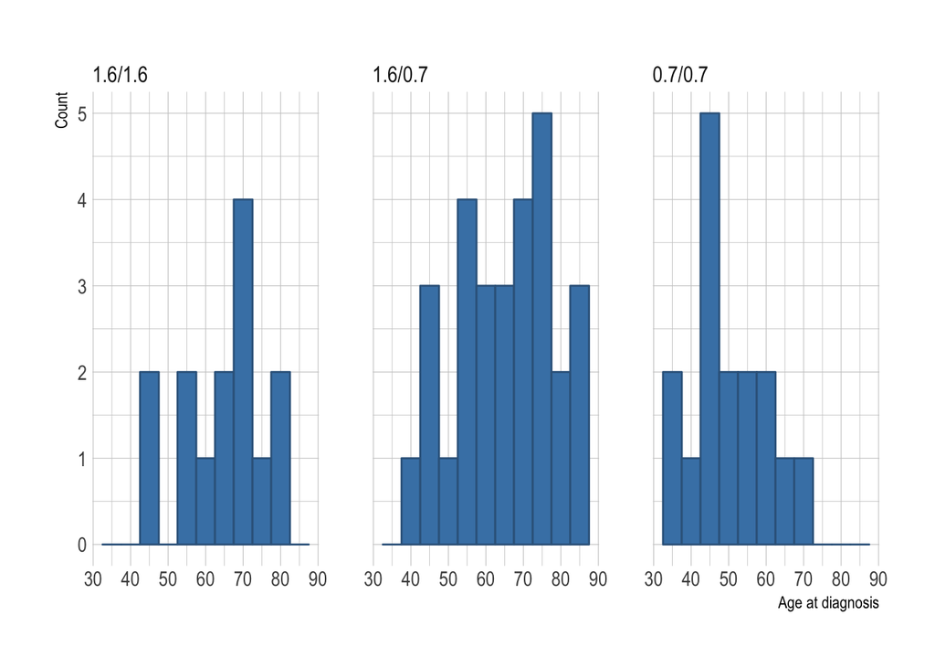

```r
p <- ggplot(data = d, aes(x = age)) +
       geom_histogram(binwidth = 5, fill = "steelblue", color = "steelblue4") +
       facet_wrap(~ genotype, ncol = 3) +
       labs(x = "Age at diagnosis", y = "Count")
p
```

## Modélisation

La commande `aov` permet de décomposer la variance totale entre les différentes sources de variations (nécessairement de type `factor`) indiquées dans le modèle et le terme d’erreur ou “résiduelle”. On l’utilise généralement en combinaison avec `summary.aov` pour produire le tableau d’ANOVA :

```r
m <- aov(age ~ genotype, data = d)
summary(m)
```

```
##             Df Sum Sq Mean Sq F value  Pr(>F)
## genotype     2   2316    1158    7.86 0.00098
## Residuals   56   8246     147
```

Une représentation graphique sous forme de moyennes conditionnelles s’obtient assez facilement avec `ggplot2`. Le calcul des moyennes et des intervalles de confiance à 95 % est réalisé avec `Hmisc` (attention, `summarize` n’accepte pas de notation par formule, contrairement à la fonction `summary.formula` du même package) :

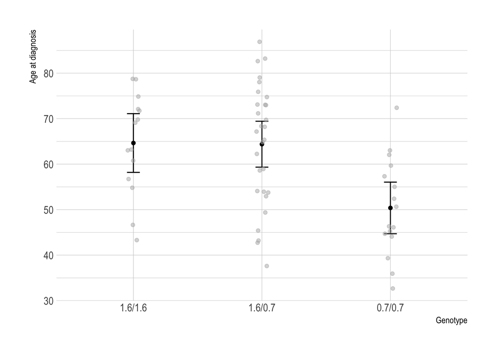

```r
r <- with(d, summarize(age, genotype, smean.cl.normal))
p <- ggplot(data = r, aes(x = genotype, y = age)) +
       geom_errorbar(aes(ymin = Lower, ymax = Upper), width=.1) +
       geom_point() +
       geom_jitter(data = d, width = .05, color = grey(.7), alpha = .5) +
       labs(x = "Genotype", y = "Age at diagnosis")
p
```

On peut comparer l’ensemble des paires de moyennes à l’aide de simples tests de Student non protégés :

```r
with(d, pairwise.t.test(age, genotype, p.adj = "none"))
```

```
##
##  Pairwise comparisons using t tests with pooled SD
##
## data:  age and genotype
##
##         1.6/1.6 1.6/0.7
## 1.6/0.7 0.947   -
## 0.7/0.7 0.002   5e-04
##
## P value adjustment method: none
```

Notons que l’option par défaut retenue pour `pairwise.t.test` est de travailler avec la variance commune de l’ensemble des groupes, comme dans l’ANOVA. Pour retrouver les mêmes résultats avec la commande `t.test`, il faudra désactiver cette option :

```r
with(d, pairwise.t.test(age, genotype, p.adj = "none", pool.sd = FALSE))
```

```
##
##  Pairwise comparisons using t tests with non-pooled SD
##
## data:  age and genotype
##
##         1.6/1.6 1.6/0.7
## 1.6/0.7 0.946   -
## 0.7/0.7 0.001   4e-04
##
## P value adjustment method: none
```

```r
t.test(age ~ genotype, data = d, subset = genotype != "0.7/0.7", var.equal = TRUE)
```

```
##
##  Two Sample t-test
##
## data:  age by genotype
## t = 0.06408, df = 41, p-value = 0.949
## alternative hypothesis: true difference in means is not equal to 0
## 95 percent confidence interval:
##  -8.04237  8.56947
## sample estimates:
## mean in group 1.6/1.6 mean in group 1.6/0.7
##               64.6429               64.3793
```

Les mêmes résultats peuvent se retrouver à partir du modèle linéaire directement. Encore une fois, il faut s’assurer que les variables catégorielles sont bien représentées comme des facteurs sous R :

```r
m <- lm(age ~ genotype, data = d)
summary(m)
```

```
##
## Call:
## lm(formula = age ~ genotype, data = d)
##
## Residuals:
##     Min      1Q  Median      3Q     Max
## -26.379  -8.643   0.625   8.621  22.621
##
## Coefficients:
##                 Estimate Std. Error t value Pr(>|t|)
## (Intercept)       64.643      3.243   19.93   <2e-16
## genotype1.6/0.7   -0.264      3.949   -0.07   0.9470
## genotype0.7/0.7  -14.268      4.441   -3.21   0.0022
##
## Residual standard error: 12.1 on 56 degrees of freedom
## Multiple R-squared:  0.219,  Adjusted R-squared:  0.191
## F-statistic: 7.86 on 2 and 56 DF,  p-value: 0.000978
```

Le test d’ensemble pour le modèle indiqué au bas des résultats précédents correspond au test de Fisher-Snedecor de l’ANOVA. On peut également le retrouver en affichant le tableau d’ANOVA du modèle de régression à l’aide de `anova` :

```r
anova(m)
```

```
## Analysis of Variance Table
##
## Response: age
##           Df Sum Sq Mean Sq F value   Pr(>F)
## genotype   2   2316  1157.9   7.863 0.000978
## Residuals 56   8246   147.2
```

# Modèle d’ANOVA à deux facteurs

Soit $y_{ijk}$ la $k$ème observation pour le niveau $i$ du facteur $A$ ($i=1,\dots,a$) et le niveau $j$ du facteur $B$ ($j=1,\dots,b$). Le modèle complet avec interaction s’écrit
$$y_{ijk} = \mu + \alpha_i + \beta_j + \gamma_{ij} + \varepsilon_{ijk},$$
où $\mu$ désigne la moyenne générale, $\alpha_i$ ($\beta_j$) l’écart à la moyenne des moyennes de groupe pour le facteur $A$ ($B$), $\gamma_{ij}$ les écarts à la moyenne des moyennes pour les traitements $A\times B$, et $\varepsilon_{ijk}\sim \mathcal{N}(0,\sigma^2)$ la résiduelle. Les effets $\alpha_i$ et $\beta_j$ sont appelés effets principaux, tandis que $\gamma_{ij}$ est l’effet d’interaction. Les hypothèses nulles associées sont
$$\left\{\begin{array}{lr}
H_0^A:\alpha_1=\alpha_2=\dots=\alpha_a, & (a-1)\,\text{dl}\\
H_0^B:\beta_1=\beta_2=\dots=\beta_b, & (b-1)\,\text{dl}\\
H_0^{AB}:\gamma_{11}=\gamma_{13}=\dots=\gamma_{ab}, &(a-1)(b-1)\,\text{dl}\\
\end{array}\right.$$

Des tests F (CM effets / CM résiduelle) permettent de tester ces hypothèses. À noter : des sommes de carré de type I sont estimées pour $A$, puis $B$, et enfin $A\times B$, à la différence des SC de type II/III, mais elles sont égales dans le cas d’un plan complet équilibré.

## Chargement des données

On utilise les données sur le gain de poids chez des rats soumis à différents régimes alimentaires, `weight.rda`. Le chargement des données est réalisé ci-dessous :

```r
load("data/weight.rda")
str(weight)
```

```
## 'data.frame':    10 obs. of  4 variables:
##  $ V1: int  90 76 90 64 86 51 72 90 95 78
##  $ V2: int  73 102 118 104 81 107 100 87 117 111
##  $ V3: int  107 95 97 80 98 74 74 67 89 58
##  $ V4: int  98 74 56 111 95 88 82 77 86 92
```

## Description des variables

Les variables peuvent être décrites par colonnes mais il est préférable de réarranger le tableau sous forme de data frame, afin d’avoir une seule variable statistique par colonne :

```r
d <- data.frame(weight = as.numeric(unlist(weight)),
                type   = gl(2, 20, labels = c("Beef", "Cereal")),
                level  = gl(2, 10, labels = c("Low", "High")))
head(d)
```

```
##   weight type level
## 1     90 Beef   Low
## 2     76 Beef   Low
## 3     90 Beef   Low
## 4     64 Beef   Low
## 5     86 Beef   Low
## 6     51 Beef   Low
```

Voici un résumé graphique possible des données individuelles avec le package `ggplot2` :

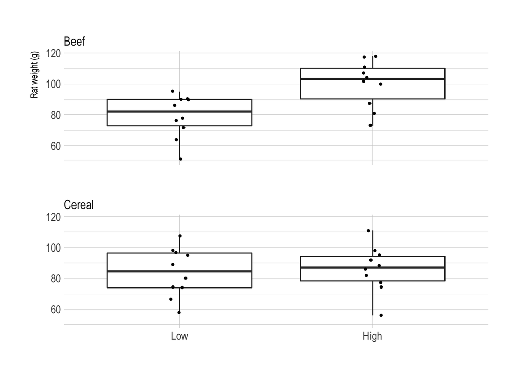

```r
p <- ggplot(data = d, aes(x = level, y = weight)) +
       geom_boxplot(position = position_dodge()) +
       geom_jitter(size = .8, width = .05) +
       facet_wrap(~ type, nrow = 2) +
       labs(x = NULL, y = "Rat weight (g)")
p
```

## Diagramme d’interaction

Pour visualiser l’interaction entre les deux variables, on peut utiliser un simple tracé de moyennes conditionnelles :

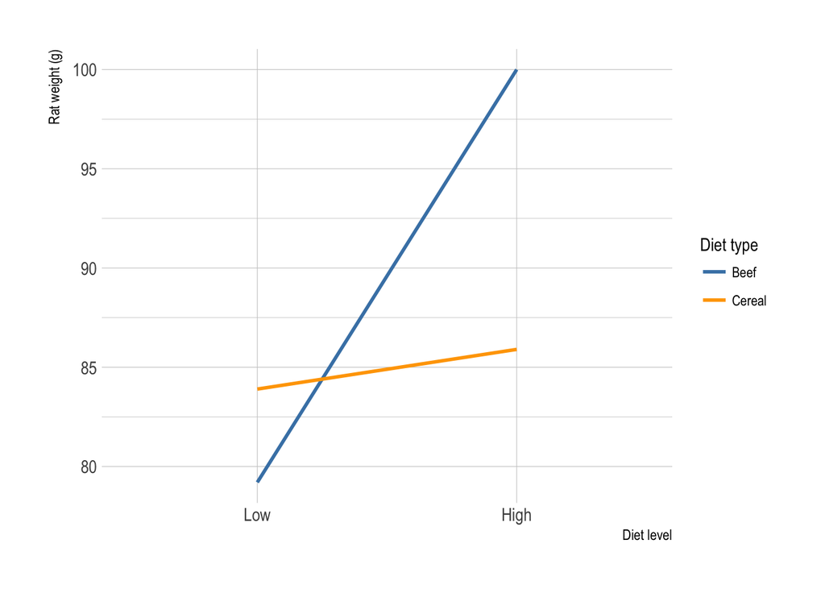

```r
p <- ggplot(data = d, aes(x = level, y = weight, color = type)) +
       stat_summary(fun.y = mean, geom = "line", aes(group = type), size = 1) +
       scale_color_manual("Diet type", values = c("steelblue", "orange")) +
       labs(x = "Diet level", y = "Rat weight (g)")
p
```

Une autre manière de procéder consisterait à travailler avec le data frame de données agrégées, `r`, et utiliser `geom_line` au lieu de `stat_summary`, toujours en veillant à ajouter une esthétique de groupement. La fonction `geom_errorbar` permet de rajouter aisément des barres d’erreur (écart-type, erreur-type ou intervalles de confiance – à calculer séparément), comme on l’a vu plus haut. Les statistiques nécessaires peuvent être calculées avec les packages `plyr`, `dplyr` ou `Hmisc` comme proposé plus haut. Voici un exemple avec des intervalles de confiance à 95 % :

```r
with(d, summarize(weight, llist(type, level), smean.cl.normal))
```

```
##     type level weight   Lower    Upper
## 2   Beef   Low   79.2 69.2660  89.1340
## 1   Beef  High  100.0 89.1721 110.8279
## 4 Cereal   Low   83.9 72.6626  95.1374
## 3 Cereal  High   85.9 75.1540  96.6460
```

Le package `Hmisc` propose aussi des fonctions graphiques pour représenter, entre autres, les effets d’interaction.

## Modélisation

Le modèle d’ANOVA à deux facteurs avec interaction s’écrit :

```r
m1 <- aov(weight ~ type * level, data = d)
summary(m1)
```

```
##             Df Sum Sq Mean Sq F value Pr(>F)
## type         1    221     221    0.99  0.327
## level        1   1300    1300    5.81  0.021
## type:level   1    884     884    3.95  0.054
## Residuals   36   8049     224
```

La notation `type * level` est équivalente à `type + level + type:level`, où `type:level` désigne l’interaction entre les facteurs `type` et `level`. Ce terme d’interaction n’étant pas significatif, il est possible de proposer un modèle plus simple :

```r
m0 <- aov(weight ~ type + level, data = d)
summary(m0)
```

```
##             Df Sum Sq Mean Sq F value Pr(>F)
## type         1    221     221    0.91  0.345
## level        1   1300    1300    5.38  0.026
## Residuals   37   8933     241
```

On retrouvera le test de l’interaction en comparant ces deux modèles emboîtés, `m0` et `m1`, à l’aide de `anova` (dans le cas gaussien, ce sont des statistiques F qui sont calculées) :

```r
anova(m0, m1)
```

```
## Analysis of Variance Table
##
## Model 1: weight ~ type + level
## Model 2: weight ~ type * level
##   Res.Df  RSS Df Sum of Sq     F Pr(>F)
## 1     37 8933
## 2     36 8049  1     883.6 3.952 0.0545
```

Puisque la variable `level` possède deux niveaux, il est également possible de retrouver à peu près les mêmes résultats que ceux du tableau d’ANOVA à l’aide d’un test de Student puisque l’effet de ce facteur est supposé être indépendant de l’autre terme inclus dans le modèle :

```r
r <- t.test(weight ~ level, data = d, var.equal = TRUE)
r
```

```
##
##  Two Sample t-test
##
## data:  weight by level
## t = -2.323, df = 38, p-value = 0.0256
## alternative hypothesis: true difference in means is not equal to 0
## 95 percent confidence interval:
##  -21.33588  -1.46412
## sample estimates:
##  mean in group Low mean in group High
##              81.55              92.95
```

```r
r$statistic^2
```

```
##       t
## 5.39495
```

## Comparaisons multiples

La fonction `pairwise.t.test` est limitée au cas à un facteur. On peut néanmoins reconstruire le terme d’interaction à l’aide de `interaction`, ce qui nous fournira un facteur codant les groupes issus du croisement de l’ensemble des niveaux des deux facteurs, encore appelé traitements. Cette technqiue permet également de réaliser un test d’égalité des variances ou de visualiser la distribution entre traitements pour vérifier les conditions de validité du modèle.

Voici un exemple de tests de Student avec correction de Bonferroni :

```r
with(d, pairwise.t.test(weight, interaction(type, level), p.adj = "bonf"))
```

```
##
##  Pairwise comparisons using t tests with pooled SD
##
## data:  weight and interaction(type, level)
##
##             Beef.Low Cereal.Low Beef.High
## Cereal.Low  1.00     -          -
## Beef.High   0.02     0.13       -
## Cereal.High 1.00     1.00       0.25
##
## P value adjustment method: bonferroni
```

Et voici pour la distribution du poids des rats entre traitements :

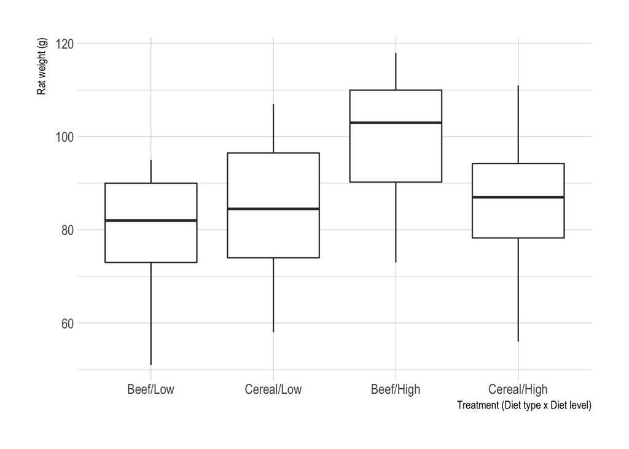

```r
p <- ggplot(data = d, aes(x = interaction(type, level, sep = "/"), y = weight)) +
       geom_boxplot() +
       labs(x = "Treatment (Diet type x Diet level)", y = "Rat weight (g)")
p
```

L’alternative consiste à utiliser des tests post-hoc de type Tukey HSD à l’aide de `TukeyHSD`, ou de l’alternative disponible via la fonction `multcomp::glht()`. Voici une illustration avec le package `multcomp`, plus flexible et plus générale que la fonction de base de R. À noter qu’il est également nécessaire de travailler avec le terme d’interaction et d’utiliser `lm` au lieu de `aov` :

```r
d$tx <- with(d, interaction(type, level))
m <- lm(weight ~ tx, data = d)
r <- glht(m, linfct = mcp(tx = "Tukey"))
summary(r)
```

```
##
##   Simultaneous Tests for General Linear Hypotheses
##
## Multiple Comparisons of Means: Tukey Contrasts
##
##
## Fit: lm(formula = weight ~ tx, data = d)
##
## Linear Hypotheses:
##                               Estimate Std. Error t value Pr(>|t|)
## Cereal.Low - Beef.Low == 0        4.70       6.69    0.70    0.895
## Beef.High - Beef.Low == 0        20.80       6.69    3.11    0.018
## Cereal.High - Beef.Low == 0       6.70       6.69    1.00    0.749
## Beef.High - Cereal.Low == 0      16.10       6.69    2.41    0.094
## Cereal.High - Cereal.Low == 0     2.00       6.69    0.30    0.991
## Cereal.High - Beef.High == 0    -14.10       6.69   -2.11    0.170
## (Adjusted p values reported -- single-step method)
```

Ces résultats vont dans le même sens que ce que suggère le résultat non significatif pour le test de l’interaction (cf. les deux comparaisons extrêmes `Cereal.Low - Beef.Low` et `Cereal.High - Beef.High`).

# Exercices d’application

Dans cette application, on travaillera avec le data frame `ToothGrowth` qui contient des données issues d’un plan d’expérience dans lequel on s’intéresse à la croissance des odontoblastes de cochons d’inde auxquels on administre de la vitamine C sous forme d’acide ascorbique ou de jus d’orange à différentes doses (0.5, 1 et 2 mg/jour).

Les données sont disponibles dans le package `datasets`. Il n’est pas forcément nécessaire de les charger dans l’espace de travail mais par souci de clarté on indique la commande requise :

```r
data(ToothGrowth)
summary(ToothGrowth)
```

```
##       len       supp         dose
##  Min.   : 4.2   OJ:30   Min.   :0.50
##  1st Qu.:13.1   VC:30   1st Qu.:0.50
##  Median :19.2           Median :1.00
##  Mean   :18.8           Mean   :1.17
##  3rd Qu.:25.3           3rd Qu.:2.00
##  Max.   :33.9           Max.   :2.00
```

Voici une vue d’ensemble des données individuelles et agrégées :

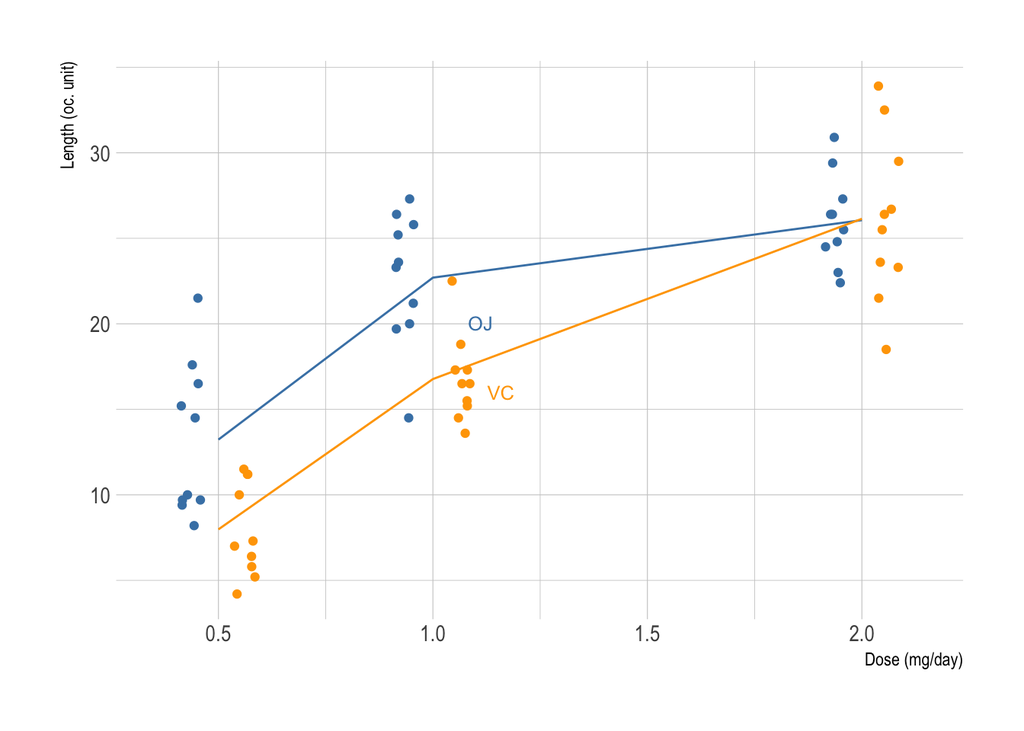

```r
r <- aggregate(len ~ dose + supp, data = ToothGrowth, mean)
p <- ggplot(data = ToothGrowth, aes(x = dose, y = len, color = supp)) +
       geom_point(position = position_jitterdodge(jitter.width = .1, dodge.width = 0.25)) +
       geom_line(data = r, aes(x = dose, y = len, color = supp)) +
       scale_color_manual(values = c("steelblue", "orange")) +
       guides(color = FALSE) +
       geom_dl(aes(label = supp), method = list("smart.grid", cex = .8)) +
       labs(x = "Dose (mg/day)", y = "Length (oc. unit)")
p
```

## Test de linéarité

Attention au codage de de la variable `dose`.

1. Réaliser une ANOVA à deux facteurs pour répondre aux questions suivantes : (a) existe t-il un effet du mode d’administration de la vitamine C (`supp`) sur la longueur des odontoblastes, et (b) cet effet est-il dépendant du dosage journalier ?
2. L’effet dose est-il linéaire ? Vérifier la linéarité de la relation `len ~ dose` en utilisant (a) une approche de régression et (b) une approche par ANOVA avec des contrastes polynomiaux.

## Comparaisons post-hoc

On souhaite comparer l’ensemble des paires de moyennes pour le croisement des deux variables `supp` et `dose`.

1. Indiquer les résultats obtenus avec une approche par tests de Student sans correction pour les tests multiples.
2. Idem mais en contrôlant pour le risque d’expérience global (FWER) par (a) une technique d’ensemble (Bonferroni ou Sidák) et (b) une technique par étape (Holm). Les conclusions diffèrent-elles ?

## Spécification de contrastes

On souhaite comparer des groupes spécifiques d’observations.

1. On s’intéresse à la comparaison des données moyennes dans le groupe `OJ` pour les doses 0.5 et 1 mg réunies avec les données moyennes dans le groupe `VC` pour les mêmes doses. Réaliser le test correspondant.
2. On s’intéresse à la comparaison des données moyennes dans le groupe `OJ` pour les doses 0.5 et 1 mg réunies avec les données moyennes dans le groupe `OJ` pour la dose 2 mg. Réaliser le test correspondant.
3. On s’intéresse à la comparaison des données moyennes dans le groupe `OJ` pour les doses 0.5 et 1 mg réunies avec les données moyennes dans le groupe `VC` pour les doses 1 et 2 mg. Réaliser le test correspondant.

## Type de sommes de carré

R utilise des sommes de carré de type I, encore appelées séquentielles. Dans le cas où les effectifs sont balancés entre les traitements, on obtiendra les mêmes résultats quelle que soit l’approche utilisée. En cas de désquilibre d’effectifs, en revanche, ce n’est plus le cas et certains auteurs recommendent d’utiliser des sommes de carré de type III, voire de type II. Comparer les résultats obtenus en utilisant ces trois types de sommes de carré, obtenus à l’aide des fonctions `add11` ou `drop1` et `Anova` du package `car` pour le modèle à deux facteurs sur les données `ToothGrowth`. Le déséquilibre d’effectifs pourra être imposé par une suppression aléatoire de 10 % des observations.

```r
set.seed(101)
ToothGrowth[sample(1:nrow(ToothGrowth), 6),"len"] <- NA
```